# Python_Data_Analysis

## Mini report

In this project I analysis the land values of differents areas in France using the datasets from 'https://www.data.gouv.fr/fr/datasets/demandes-de-valeurs-foncieres/'.

I started this project by selecting most useful assets from the dataset. I then observesd the obtained pandas DataFrame and processed the data to allow a deep data analysis later given that I already had my visualization ideas in mind.

However, I still encountered a problem: some data was outlier, such as the exorbitant price per square meter in Brittany compared to the rest of France. To address this issue, I performed a more thorough data cleaning.

I decided to focus on comparisons between regions and departments. For the comparison between four years, I choose 2024 and 2020, the latter being an interesting year due to the Covid-19 pandemic.

Finally, I created two visualizations on Django: the property value by type of property and by month, as well as a map of France showing the property value by region.

## Import of libraries

```python
import pandas as pd
import numpy as np
import matplotlib.pyplot as plt
import seaborn as sns
import folium
import json
import plotly.express as px
```

## Import files and data processing

```python
# Select the columns we want to keep/study
colonne_cons= [
    "Date mutation",
    "Valeur fonciere",
    "Code postal",
    "Commune",
    "Code departement",
    "Code commune",
    "Type local",
    "Nombre pieces principales",
    "Nature culture",
    "Surface terrain",
    "Surface reelle bati"
]
```

```python
df2024 = pd.read_csv('ValeursFoncieres-2024.txt', sep='|', usecols=colonne_cons, dtype={18: str, 23: str, 41: str, 24: str, 26: str, 28: str, 29: str, 31: str, 33: str})
print("Le nombre de lignes est :", df2024.shape[0])
df2024 = df2024[df2024['Valeur fonciere'].notna()]
df2024['Valeur fonciere'] = df2024['Valeur fonciere'].str.replace(',', '.').astype(float)
```

```
Le nombre de lignes est : 3458643
```

```python
df2020 = pd.read_csv('Valeursfoncieres-2020.txt', sep='|', decimal=",",usecols=colonne_cons,dtype={11: str, 18: str, 23: str,41: str, 24: str, 26: str, 28: str, 29: str, 31: str, 33: str})
print("Le nombre de lignes est :", df2020.shape[0])
df2020= df2020[df2020['Valeur fonciere'].notna()]
# df2020['Valeur fonciere'] = df2020['Valeur fonciere'].str.replace(',', '.').astype(float)
```

```
Le nombre de lignes est : 3522416
```

```python
df2024
```

|  | Date mutation | Valeur fonciere | Code postal | Commune | Code departement | Code commune | Type local | Surface reelle bati | Nombre pieces principales | Nature culture | Surface terrain |
| --- | --- | --- | --- | --- | --- | --- | --- | --- | --- | --- | --- |
| 0 | 02/01/2024 | 346.5 | 1230.0 | CHALEY | 01 | 76 | NaN | NaN | NaN | P | 99.0 |
| 1 | 03/01/2024 | 10000.0 | 1170.0 | CHEVRY | 01 | 103 | NaN | NaN | NaN | S | 115.0 |
| 2 | 08/01/2024 | 249000.0 | 1290.0 | LAIZ | 01 | 203 | NaN | NaN | NaN | S | 497.0 |
| 3 | 03/01/2024 | 329500.0 | 1170.0 | GEX | 01 | 173 | Dépendance | 0.0 | 0.0 | NaN | NaN |
| 4 | 03/01/2024 | 329500.0 | 1170.0 | GEX | 01 | 173 | Dépendance | 0.0 | 0.0 | NaN | NaN |
| ... | ... | ... | ... | ... | ... | ... | ... | ... | ... | ... | ... |
| 3458638 | 28/11/2024 | 4550000.0 | 75012.0 | PARIS 12 | 75 | 112 | Appartement | 23.0 | 2.0 | S | 323.0 |
| 3458639 | 28/11/2024 | 4550000.0 | 75012.0 | PARIS 12 | 75 | 112 | Appartement | 23.0 | 2.0 | S | 323.0 |
| 3458640 | 28/11/2024 | 4550000.0 | 75012.0 | PARIS 12 | 75 | 112 | Appartement | 23.0 | 2.0 | S | 323.0 |
| 3458641 | 28/11/2024 | 4550000.0 | 75012.0 | PARIS 12 | 75 | 112 | Appartement | 23.0 | 2.0 | S | 323.0 |
| 3458642 | 28/11/2024 | 4550000.0 | 75012.0 | PARIS 12 | 75 | 112 | Local industriel. commercial ou assimilé | 42.0 | 0.0 | S | 323.0 |

3422092 rows × 11 columns

```python
def format_code_postal(cp):
    if pd.isna(cp):
        return None
    cp = int(float(cp))
    cp_str = str(cp)
    if len(cp_str) < 5:
        cp_str = cp_str.ljust(5, '0')
    return cp_str

df2024['Code postal'] = df2024['Code postal'].apply(format_code_postal)
df2020['Code postal'] = df2020['Code postal'].apply(format_code_postal)
```

```python
df2024
```

|  | Date mutation | Valeur fonciere | Code postal | Commune | Code departement | Code commune | Type local | Surface reelle bati | Nombre pieces principales | Nature culture | Surface terrain |
| --- | --- | --- | --- | --- | --- | --- | --- | --- | --- | --- | --- |
| 0 | 02/01/2024 | 346.5 | 12300 | CHALEY | 01 | 76 | NaN | NaN | NaN | P | 99.0 |
| 1 | 03/01/2024 | 10000.0 | 11700 | CHEVRY | 01 | 103 | NaN | NaN | NaN | S | 115.0 |
| 2 | 08/01/2024 | 249000.0 | 12900 | LAIZ | 01 | 203 | NaN | NaN | NaN | S | 497.0 |
| 3 | 03/01/2024 | 329500.0 | 11700 | GEX | 01 | 173 | Dépendance | 0.0 | 0.0 | NaN | NaN |
| 4 | 03/01/2024 | 329500.0 | 11700 | GEX | 01 | 173 | Dépendance | 0.0 | 0.0 | NaN | NaN |
| ... | ... | ... | ... | ... | ... | ... | ... | ... | ... | ... | ... |
| 3458638 | 28/11/2024 | 4550000.0 | 75012 | PARIS 12 | 75 | 112 | Appartement | 23.0 | 2.0 | S | 323.0 |
| 3458639 | 28/11/2024 | 4550000.0 | 75012 | PARIS 12 | 75 | 112 | Appartement | 23.0 | 2.0 | S | 323.0 |
| 3458640 | 28/11/2024 | 4550000.0 | 75012 | PARIS 12 | 75 | 112 | Appartement | 23.0 | 2.0 | S | 323.0 |
| 3458641 | 28/11/2024 | 4550000.0 | 75012 | PARIS 12 | 75 | 112 | Appartement | 23.0 | 2.0 | S | 323.0 |
| 3458642 | 28/11/2024 | 4550000.0 | 75012 | PARIS 12 | 75 | 112 | Local industriel. commercial ou assimilé | 42.0 | 0.0 | S | 323.0 |

3422092 rows × 11 columns

```python
df2024['Date mutation'] = pd.to_datetime(df2024['Date mutation'], format='%d/%m/%Y')
df2020['Date mutation'] = pd.to_datetime(df2020['Date mutation'], format='%d/%m/%Y')

# Create a new column 'Mois' (month) from the mutation date for 2024 data
df2024['Mois'] = df2024['Date mutation'].dt.month

# Create a new column 'Mois' (month) from the mutation date for 2020 data
df2020['Mois'] = df2020['Date mutation'].dt.month
```

We remove outlier data on property values using a mean, standard deviation rule.

```python
mean_value2024 = df2024["Valeur fonciere"].mean()
std_value2024 = df2024["Valeur fonciere"].std()

outlier_limit2024 = mean_value2024 + 7 * std_value2024

df2024 = df2024[df2024["Valeur fonciere"] <= outlier_limit2024]
```

```python
#display(df2024["Code departement"].value_counts())
print("Le nombre de lignes est :", df2024.shape[0])
```

```
Le nombre de lignes est : 3409845
```

```python
mean_value2020 = df2020["Valeur fonciere"].mean()
std_value2020 = df2020["Valeur fonciere"].std()

outlier_limit2020 = mean_value2020 + 7 * std_value2020

df2020 = df2020[df2020["Valeur fonciere"] <= outlier_limit2020]
```

We group the departments by regions.

```python
# Remove Corsican departments (2A, 2B) from the dataframe
df2024 = df2024.drop(df2024[df2024['Code departement'].isin(['2A', '2B'])].index)
df2024['Code departement'] = df2024['Code departement'].astype(str)

# Define department codes for each region
auvergne_rhone_alpes = ['1', '3', '7', '15', '26', '38', '42', '43', '63', '69', '73', '74']
bourgogne_franche_comte = ['21', '25', '39', '58', '70', '71', '89', '90']
bretagne = ['22', '29', '35', '56']
centre_val_de_loire = ['18', '28', '36', '37', '41', '45']
corse = ['2A', '2B']
grand_est = ['8', '10', '51', '52', '54', '55', '57', '67', '68', '88']
hauts_de_france = ['02', '59', '60', '62', '80']
ile_de_france = ['75', '77', '78', '91', '92', '93', '94', '95']
normandie = ['14', '27', '50', '61', '76']
nouvelle_aquitaine = ['16', '17', '19', '23', '24', '33', '40', '47', '64', '79', '86', '87']
occitanie = ['9', '11', '12', '30', '31', '32', '34', '46', '48', '65', '66', '81', '82']
pays_de_la_loire = ['44', '49', '53', '72', '85']
provence_alpes_cote_dazur = ['04', '05', '06', '13', '83', '84']
# Overseas regions
guadeloupe = ['971']
martinique = ['972']
guyane = ['973']
la_reunion = ['974']
mayotte = ['976']

# Assign regions to department codes using .loc and isin
df2024.loc[df2024['Code departement'].isin(auvergne_rhone_alpes), 'Region'] = 'Auvergne-Rhône-Alpes'
df2024.loc[df2024['Code departement'].isin(bourgogne_franche_comte), 'Region'] = 'Bourgogne-Franche-Comté'
df2024.loc[df2024['Code departement'].isin(bretagne), 'Region'] = 'Bretagne'
df2024.loc[df2024['Code departement'].isin(centre_val_de_loire), 'Region'] = 'Centre-Val de Loire'
df2024.loc[df2024['Code departement'].isin(corse), 'Region'] = 'Corse'
df2024.loc[df2024['Code departement'].isin(grand_est), 'Region'] = 'Grand Est'
df2024.loc[df2024['Code departement'].isin(hauts_de_france), 'Region'] = 'Hauts-de-France'
df2024.loc[df2024['Code departement'].isin(ile_de_france), 'Region'] = 'Île-de-France'
df2024.loc[df2024['Code departement'].isin(normandie), 'Region'] = 'Normandie'
df2024.loc[df2024['Code departement'].isin(nouvelle_aquitaine), 'Region'] = 'Nouvelle-Aquitaine'
df2024.loc[df2024['Code departement'].isin(occitanie), 'Region'] = 'Occitanie'
df2024.loc[df2024['Code departement'].isin(pays_de_la_loire), 'Region'] = 'Pays de la Loire'
df2024.loc[df2024['Code departement'].isin(provence_alpes_cote_dazur), 'Region'] = 'Provence-Alpes-Côte d\'Azur'
df2024.loc[df2024['Code departement'].isin(guadeloupe), 'Region'] = 'Guadeloupe'
df2024.loc[df2024['Code departement'].isin(martinique), 'Region'] = 'Martinique'
df2024.loc[df2024['Code departement'].isin(guyane), 'Region'] = 'Guyane'
df2024.loc[df2024['Code departement'].isin(la_reunion), 'Region'] = 'La Réunion'
df2024.loc[df2024['Code departement'].isin(mayotte), 'Region'] = 'Mayotte'

# Check that regions have been correctly assigned
display(df2024.info())
```

```
<class 'pandas.core.frame.DataFrame'>
Index: 3392893 entries, 0 to 3458642
Data columns (total 13 columns):
 #   Column                     Dtype
---  ------                     -----
 0   Date mutation              datetime64[ns]
 1   Valeur fonciere            float64
 2   Code postal                object
 3   Commune                    object
 4   Code departement           object
 5   Code commune               int64
 6   Type local                 object
 7   Surface reelle bati        float64
 8   Nombre pieces principales  float64
 9   Nature culture             object
 10  Surface terrain            float64
 11  Mois                       int32
 12  Region                     object
dtypes: datetime64[ns](1), float64(4), int32(1), int64(1), object(6)
memory usage: 349.5+ MB
```

```
None
```

```python
# Remove Corsican departments (2A, 2B) from the dataframe
df2020 = df2020.drop(df2020[df2020['Code departement'].isin(['2A', '2B'])].index)
df2020['Code departement'] = df2020['Code departement'].astype(str)

# Define department codes for each region
auvergne_rhone_alpes = ['1', '3', '7', '15', '26', '38', '42', '43', '63', '69', '73', '74']
bourgogne_franche_comte = ['21', '25', '39', '58', '70', '71', '89', '90']
bretagne = ['22', '29', '35', '56']
centre_val_de_loire = ['18', '28', '36', '37', '41', '45']
corse = ['2A', '2B']
grand_est = ['8', '10', '51', '52', '54', '55', '57', '67', '68', '88']
hauts_de_france = ['02', '59', '60', '62', '80']
ile_de_france = ['75', '77', '78', '91', '92', '93', '94', '95']
normandie = ['14', '27', '50', '61', '76']
nouvelle_aquitaine = ['16', '17', '19', '23', '24', '33', '40', '47', '64', '79', '86', '87']
occitanie = ['9', '11', '12', '30', '31', '32', '34', '46', '48', '65', '66', '81', '82']
pays_de_la_loire = ['44', '49', '53', '72', '85']
provence_alpes_cote_dazur = ['04', '05', '06', '13', '83', '84']
# Overseas regions
guadeloupe = ['971']
martinique = ['972']
guyane = ['973']
la_reunion = ['974']
mayotte = ['976']

# Assign regions to department codes using .loc and isin
df2020.loc[df2020['Code departement'].isin(auvergne_rhone_alpes), 'Region'] = 'Auvergne-Rhône-Alpes'
df2020.loc[df2020['Code departement'].isin(bourgogne_franche_comte), 'Region'] = 'Bourgogne-Franche-Comté'
df2020.loc[df2020['Code departement'].isin(bretagne), 'Region'] = 'Bretagne'
df2020.loc[df2020['Code departement'].isin(centre_val_de_loire), 'Region'] = 'Centre-Val de Loire'
df2020.loc[df2020['Code departement'].isin(corse), 'Region'] = 'Corse'
df2020.loc[df2020['Code departement'].isin(grand_est), 'Region'] = 'Grand Est'
df2020.loc[df2020['Code departement'].isin(hauts_de_france), 'Region'] = 'Hauts-de-France'
df2020.loc[df2020['Code departement'].isin(ile_de_france), 'Region'] = 'Île-de-France'
df2020.loc[df2020['Code departement'].isin(normandie), 'Region'] = 'Normandie'
df2020.loc[df2020['Code departement'].isin(nouvelle_aquitaine), 'Region'] = 'Nouvelle-Aquitaine'
df2020.loc[df2020['Code departement'].isin(occitanie), 'Region'] = 'Occitanie'
df2020.loc[df2020['Code departement'].isin(pays_de_la_loire), 'Region'] = 'Pays de la Loire'
df2020.loc[df2020['Code departement'].isin(provence_alpes_cote_dazur), 'Region'] = 'Provence-Alpes-Côte d\'Azur'
df2020.loc[df2020['Code departement'].isin(guadeloupe), 'Region'] = 'Guadeloupe'
df2020.loc[df2020['Code departement'].isin(martinique), 'Region'] = 'Martinique'
df2020.loc[df2020['Code departement'].isin(guyane), 'Region'] = 'Guyane'
df2020.loc[df2020['Code departement'].isin(la_reunion), 'Region'] = 'La Réunion'
df2020.loc[df2020['Code departement'].isin(mayotte), 'Region'] = 'Mayotte'

# Check that regions have been correctly assigned
display(df2020.info())
```

```
<class 'pandas.core.frame.DataFrame'>
Index: 3443899 entries, 0 to 3522415
Data columns (total 13 columns):
 #   Column                     Dtype
---  ------                     -----
 0   Date mutation              datetime64[ns]
 1   Valeur fonciere            float64
 2   Code postal                object
 3   Commune                    object
 4   Code departement           object
 5   Code commune               int64
 6   Type local                 object
 7   Surface reelle bati        float64
 8   Nombre pieces principales  float64
 9   Nature culture             object
 10  Surface terrain            float64
 11  Mois                       int32
 12  Region                     object
dtypes: datetime64[ns](1), float64(4), int32(1), int64(1), object(6)
memory usage: 354.7+ MB
```

```
None
```

```python
df2024.dropna(subset=['Valeur fonciere', 'Surface reelle bati', 'Region'], inplace=True)
df2024.fillna({'Valeur fonciere': 0, 'Surface reelle bati': 0, 'Region': 'Unknown'}, inplace=True)

df2024['Valeur fonciere'] = pd.to_numeric(df2024['Valeur fonciere'], errors='coerce')
df2024['Surface reelle bati'] = pd.to_numeric(df2024['Surface reelle bati'], errors='coerce')

# Option 2: Replace zeros in 'Surface reelle bati' with NaN
df2024['Surface reelle bati'].replace(0, np.nan, inplace=True)


df2020.dropna(subset=['Valeur fonciere', 'Surface reelle bati'], inplace=True)
df2020.fillna({'Valeur fonciere': 0, 'Surface reelle bati': 0}, inplace=True)

df2020['Valeur fonciere'] = pd.to_numeric(df2020['Valeur fonciere'], errors='coerce')
df2020['Surface reelle bati'] = pd.to_numeric(df2020['Surface reelle bati'], errors='coerce')

# Option 2: Replace zeros in 'Surface reelle bati' with NaN
df2020['Surface reelle bati'].replace(0, np.nan, inplace=True)
```

## Comparaison on the regions

Number of each type of property in regions in 2020 and 2024

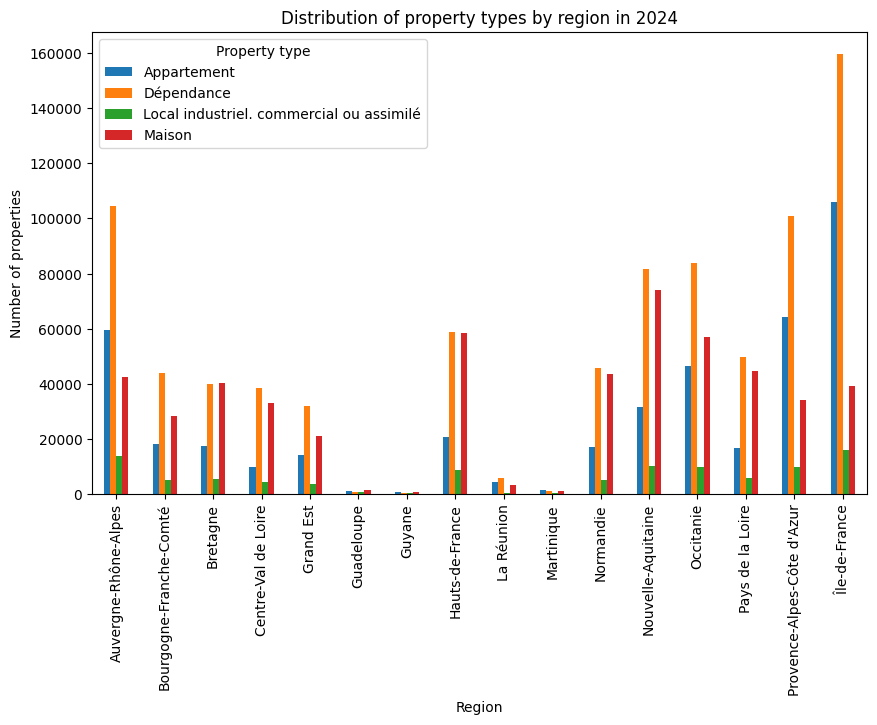

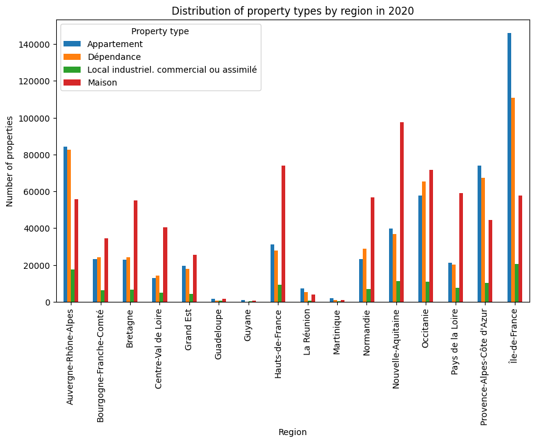

```python
# Calculate the number of each property type by region for 2024
plt.figure()
local_counts_2024 = df2024.groupby(['Region', 'Type local']).size().unstack()

# Display the stacked bar chart for 2024
local_counts_2024.plot(kind='bar', stacked=False, figsize=(10, 6))

# Add labels and title
plt.xlabel('Region')
plt.ylabel('Number of properties')
plt.title('Distribution of property types by region in 2024')

# Show legend
plt.legend(title='Property type')

# Calculate the number of each property type by region for 2020
local_counts_2020 = df2020.groupby(['Region', 'Type local']).size().unstack()

# Display the stacked bar chart for 2020
local_counts_2020.plot(kind='bar', stacked=False, figsize=(10, 6))

# Add labels and title
plt.xlabel('Region')
plt.ylabel('Number of properties')
plt.title('Distribution of property types by region in 2020')

# Show legend
plt.legend(title='Property type')

# Show the plots
plt.show()
```

Price per square meter of a house in 2020 and 2024

```python
prix_metre_carre = df2024.groupby('Type local')['Valeur fonciere'].mean() / df2024.groupby('Type local')['Surface reelle bati'].mean()
prix_metre_carre2 = df2020.groupby('Type local')['Valeur fonciere'].mean() / df2020.groupby('Type local')['Surface reelle bati'].mean()

print("Average price per square meter of a house in 2024:", prix_metre_carre.Maison)
print("Average price per square meter of a house in 2020:", prix_metre_carre2.Maison)
```

```
Average price per square meter of a house in 2024: 3123.815793196234
Average price per square meter of a house in 2020: 2633.470368898321
```

We observe the number of transactions per regions

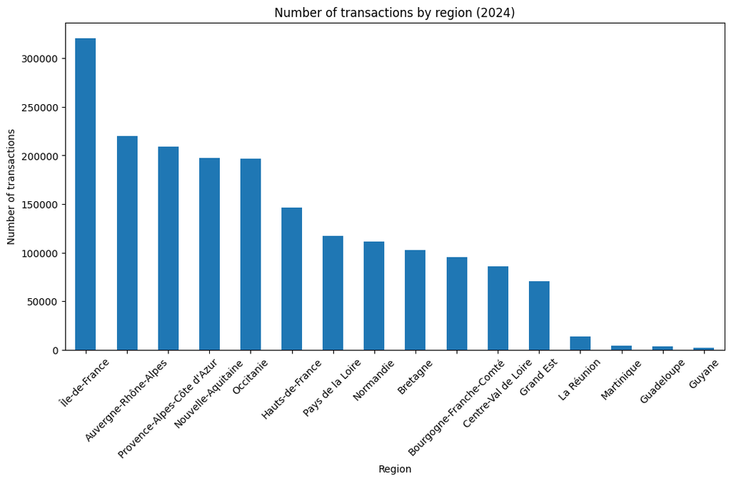

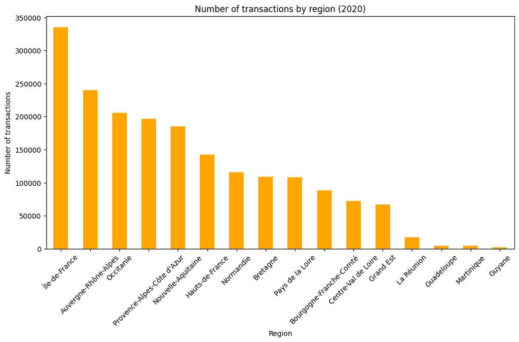

```python
# Count the number of transactions per region for 2024
mutations_by_region = df2024["Region"].value_counts()

plt.figure(figsize=(12, 6))
mutations_by_region.plot(kind="bar")
plt.title("Number of transactions by region (2024)")
plt.xlabel("Region")
plt.ylabel("Number of transactions")
plt.xticks(rotation=45)
plt.show()

# Count the number of transactions per region for 2020
mutations_by_region_2020 = df2020["Region"].value_counts()

plt.figure(figsize=(12, 6))
mutations_by_region_2020.plot(kind="bar", color="orange")
plt.title("Number of transactions by region (2020)")
plt.xlabel("Region")
plt.ylabel("Number of transactions")
plt.xticks(rotation=45)
plt.show()
```

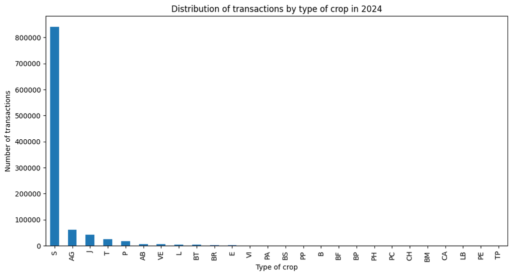

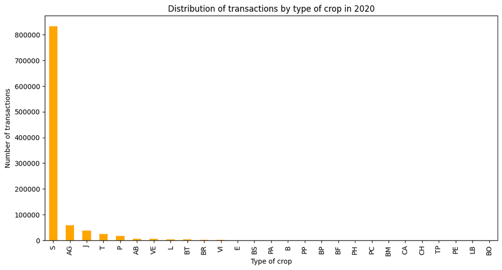

```python
# Distribution of transactions by type of crop in 2024
df2024['Nature culture'].value_counts().plot(kind='bar', figsize=(12, 6))
plt.title('Distribution of transactions by type of crop in 2024')
plt.xlabel('Type of crop')
plt.ylabel('Number of transactions')
plt.show()

# Distribution of transactions by type of crop in 2020
df2020['Nature culture'].value_counts().plot(kind='bar', figsize=(12, 6), color='orange')
plt.title('Distribution of transactions by type of crop in 2020')
plt.xlabel('Type of crop')
plt.ylabel('Number of transactions')
plt.show()
```

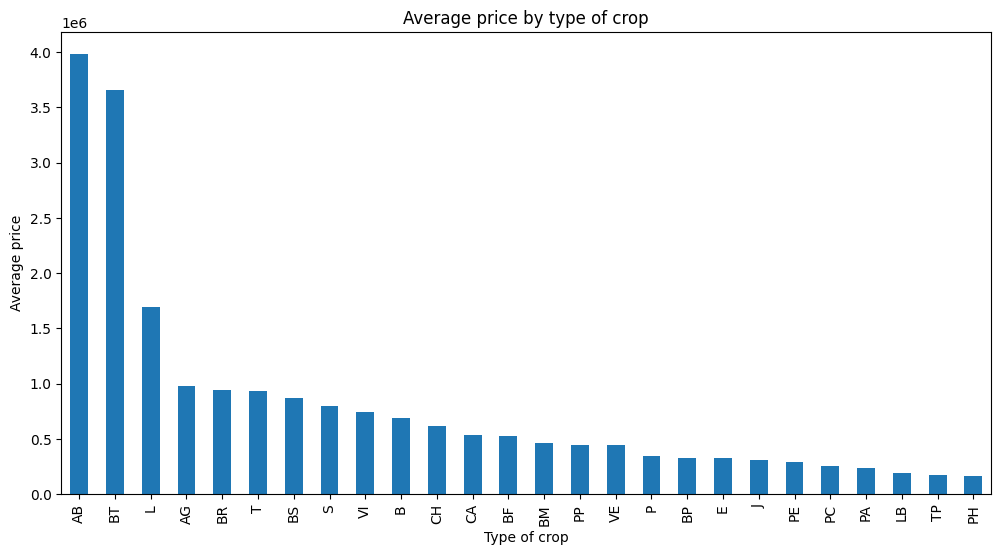

```python
# Average price by type of crop
avg_price_by_crop = df2024.groupby('Nature culture')['Valeur fonciere'].mean().sort_values(ascending=False)
avg_price_by_crop.plot(kind='bar', figsize=(12, 6))
plt.title('Average price by type of crop')
plt.xlabel('Type of crop')
plt.ylabel('Average price')
plt.show()
```

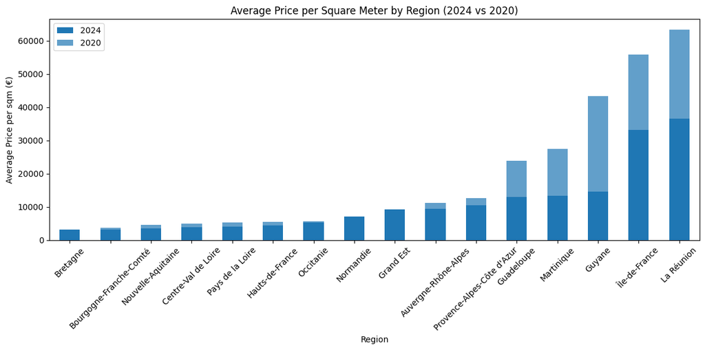

```python
# Calculate average price per square meter by region for 2024
df2024['Price per sqm'] = df2024['Valeur fonciere'] / df2024['Surface reelle bati']
avg_price_per_region = df2024.groupby('Region')['Price per sqm'].mean()

# Calculate average price per square meter by region for 2020
df2020['Price per sqm'] = df2020['Valeur fonciere'] / df2020['Surface reelle bati']
avg_price_per_region_2020 = df2020.groupby('Region')['Price per sqm'].mean()

# Plot histogram of average price per sqm by region for 2024
plt.figure(figsize=(12, 6))
avg_price_per_region.sort_values().plot(kind='bar', label='2024')
avg_price_per_region_2020.sort_values().plot(kind='bar', alpha=0.7, label='2020')
plt.title('Average Price per Square Meter by Region (2024 vs 2020)')
plt.xlabel('Region')
plt.ylabel('Average Price per sqm (€)')
plt.xticks(rotation=45)
plt.legend()
plt.tight_layout()
plt.show()
```

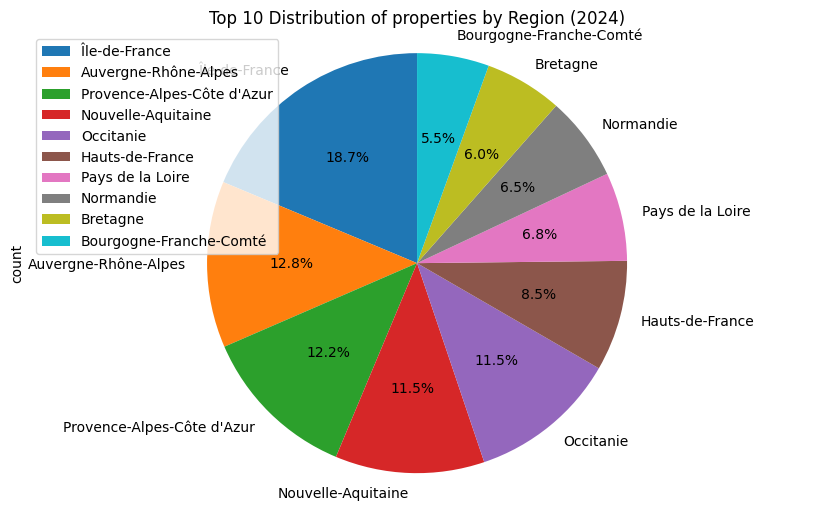

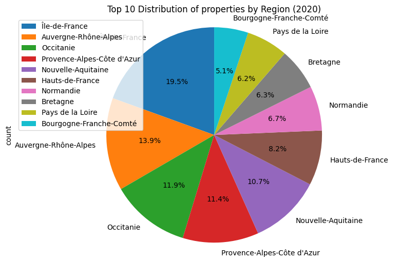

```python
# Pie chart for 2024: Distribution of properties by Region
count_by_region_2024 = df2024['Region'].value_counts()

plt.figure(figsize=(10, 6))
count_by_region_2024.head(10).plot(kind='pie', autopct='%1.1f%%', startangle=90)
plt.title('Top 10 Distribution of properties by Region (2024)')
plt.axis('equal')
plt.legend()
plt.show()

# Pie chart for 2020: Distribution of properties by Region
count_by_region_2020 = df2020['Region'].value_counts()

plt.figure(figsize=(10, 6))
count_by_region_2020.head(10).plot(kind='pie', autopct='%1.1f%%', startangle=90)
plt.title('Top 10 Distribution of properties by Region (2020)')
plt.axis('equal')
plt.legend()
plt.show()
```

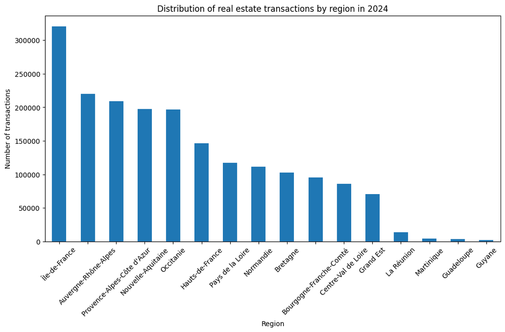

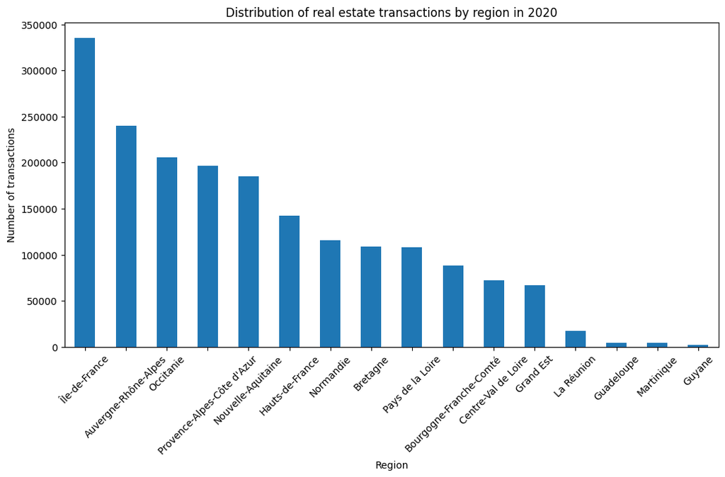

```python
# Bar chart of real estate transactions by region in 2024
region_distribution_2024 = df2024['Region'].value_counts()

plt.figure(figsize=(12, 6))
region_distribution_2024.plot(kind='bar')
plt.title('Distribution of real estate transactions by region in 2024')
plt.xlabel('Region')
plt.ylabel('Number of transactions')
plt.xticks(rotation=45)
plt.show()

# Bar chart of real estate transactions by region in 2020
region_distribution_2020 = df2020['Region'].value_counts()

plt.figure(figsize=(12, 6))
region_distribution_2020.plot(kind='bar')
plt.title('Distribution of real estate transactions by region in 2020')
plt.xlabel('Region')
plt.ylabel('Number of transactions')
plt.xticks(rotation=45)
plt.show()
```

## Observations on the evolution over time of real estate property characteristics

```python
fig = px.scatter(
    df2024,
    x="Valeur fonciere",
    y="Mois",
    color="Type local",
    hover_data=["Valeur fonciere"],
    title="Distribution of property values over the year 2024"
)

fig.show()
```

[output not shown]

```python
fig = px.scatter(
    df2020,
    x="Valeur fonciere",
    y="Mois",
    color="Type local",
    hover_data=["Valeur fonciere"],
    title="Distribution of property values over the year 2020"
)

fig.show()
```

[output not shown]

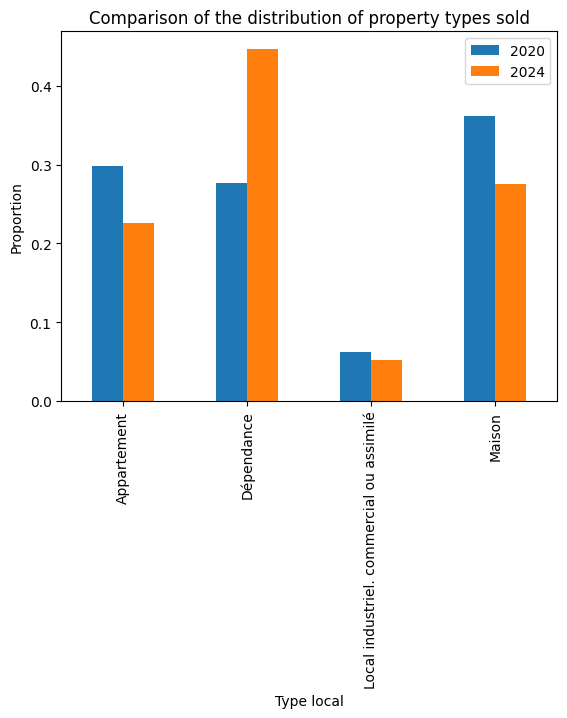

```python
type_distribution_2020 = df2020['Type local'].value_counts(normalize=True)
type_distribution_2024 = df2024['Type local'].value_counts(normalize=True)
type_distribution = pd.DataFrame({'2020': type_distribution_2020, '2024': type_distribution_2024})
type_distribution.plot(kind='bar', stacked=False)
plt.title('Comparison of the distribution of property types sold')
plt.ylabel('Proportion')
plt.show()
```

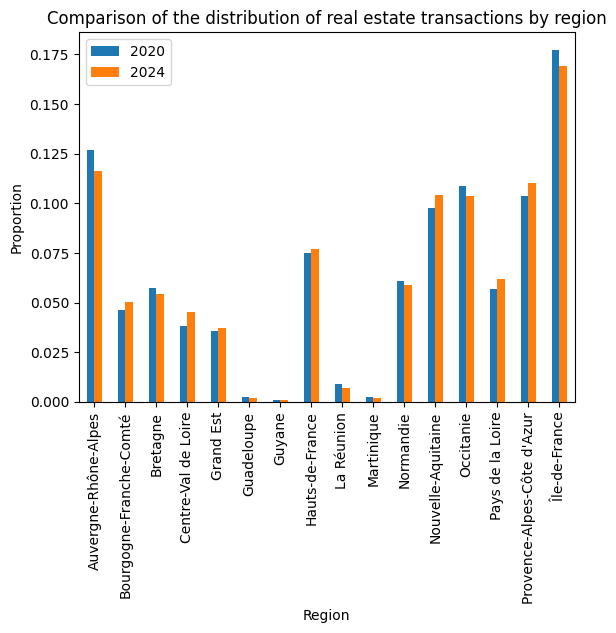

```python
#Comparison of the distribution of real estate transactions by region
region_distribution_2020 = df2020['Region'].value_counts(normalize=True)
region_distribution_2024 = df2024['Region'].value_counts(normalize=True)

df_region = pd.DataFrame({'2020': region_distribution_2020, '2024': region_distribution_2024})

df_region.plot(kind='bar', stacked=False)

plt.title('Comparison of the distribution of real estate transactions by region')
plt.ylabel('Proportion')
plt.show()
```

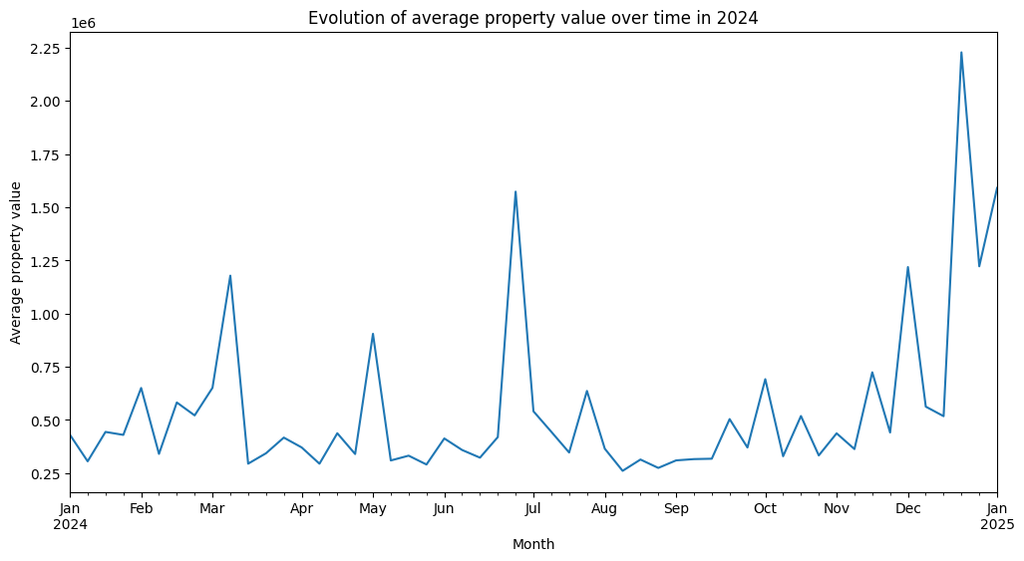

```python
import matplotlib.pyplot as plt

avg_price_over_time = df2024.groupby(df2024['Date mutation'].dt.to_period("W"))['Valeur fonciere'].mean()
avg_price_over_time.plot(kind='line', figsize=(12, 6))
plt.title('Evolution of average property value over time in 2024')
plt.xlabel('Month')
plt.ylabel('Average property value')
plt.show()
```

[figure not shown]

```python
import matplotlib.pyplot as plt
# Count the number of properties sold by region
plt.subplot(121)
property_count = df2024['Region'].value_counts()

property_count[:10].plot(kind='bar', figsize=(10,6), color="r")
# Display the 10 regions with the highest number of properties sold
plt.title('Number of properties sold by Region in 2022')
plt.xlabel('Region')
plt.ylabel('Number of properties sold')
plt.subplot(122)
property_count2 = df2020['Region'].value_counts()
property_count2[:10].plot(kind='bar', figsize=(10,6), color="b")

plt.title('Number of properties sold by Region in 2020')
plt.xlabel('Region')
plt.ylabel('Number of properties sold')
plt.show()
```